# Keystone_Species

Kaushik Surej

2026-08-18

This project was procured from a former PhD student and the work that she had carried out within the Ross River Estuary were divided into four separate datasheets, observing the ecological diversity of the water body in sight

The major issue that the project faces is in the form of how the data were compiled, because of which RStudio found it difficult to classify the data, due to the spreadsheets which contained all of the data points not adhering to the software’s case sensitive nature

# Intorduction to Complex Data Wrangling

## Step 1: Integration of all of the available files into an Rmd window

Install and load a bunch of packages first

```r
library(tidyverse)
```

```r
library(ggplot2)
library(readxl)
library(lubridate)
library(here)
```

Observing the catch data that has been provided

```r
library(readxl)

catch1 <- read_excel(
  "C:/Users/jd147368/Documents/R4MarineScience/data/workshop2/estuary_catch_log.xlsx",
  sheet = "Lower_ross"
)

catch2 <- read_excel(
  "C:/Users/jd147368/Documents/R4MarineScience/data/workshop2/estuary_catch_log.xlsx",
  sheet = 2
)

catch3 <- read_excel(
  "C:/Users/jd147368/Documents/R4MarineScience/data/workshop2/estuary_catch_log.xlsx",
  sheet = 3
)

catch4 <- read_excel(
  "C:/Users/jd147368/Documents/R4MarineScience/data/workshop2/estuary_catch_log.xlsx",
  sheet = 4
)
```

Carrying out an inspection to see if the tabs that have been loaded are the ones that are needed for the functioning of the project

```r
catch1
```

```
## # A tibble: 104 × 4
##    site       date                species       count
##    <chr>      <dttm>              <chr>         <dbl>
##  1 Lower_ross 2026-05-01 00:00:00 barramundi        6
##  2 Lower_ross 2026-05-01 00:00:00 MANGROVE JACK     3
##  3 Lower_ross 2026-05-01 00:00:00 bream             4
##  4 Lower_ross 2026-05-01 00:00:00 flathead          2
##  5 Lower_ross 2026-05-02 00:00:00 barramundi        1
##  6 Lower_ross 2026-05-02 00:00:00 MANGROVE JACK     1
##  7 Lower_ross 2026-05-02 00:00:00 bream             3
##  8 Lower_ross 2026-05-02 00:00:00 flathead          3
##  9 Lower_ross 2026-05-03 00:00:00 MANGROVE JACK     2
## 10 Lower_ross 2026-05-03 00:00:00 flathead          3
## # ℹ 94 more rows
```

```r
catch2
```

```
## # A tibble: 106 × 4
##    site     date                species       count
##    <chr>    <dttm>              <chr>         <dbl>
##  1 Mid_Ross 2026-05-01 00:00:00 barramundi        4
##  2 Mid_Ross 2026-05-01 00:00:00 MANGROVE JACK     2
##  3 Mid_Ross 2026-05-01 00:00:00 bream             2
##  4 Mid_Ross 2026-05-01 00:00:00 flathead          3
##  5 Mid_Ross 2026-05-02 00:00:00 MANGROVE JACK     1
##  6 Mid_Ross 2026-05-02 00:00:00 bream             2
##  7 Mid_Ross 2026-05-02 00:00:00 flathead          3
##  8 Mid_Ross 2026-05-03 00:00:00 barramundi        3
##  9 Mid_Ross 2026-05-03 00:00:00 MANGROVE JACK     2
## 10 Mid_Ross 2026-05-03 00:00:00 bream             1
## # ℹ 96 more rows
```

```r
catch3
```

```
## # A tibble: 107 × 4
##    site       date                species       count
##    <chr>      <dttm>              <chr>         <dbl>
##  1 ROSS MOUTH 2026-05-01 00:00:00 barramundi        3
##  2 ROSS MOUTH 2026-05-01 00:00:00 MANGROVE JACK     2
##  3 ROSS MOUTH 2026-05-01 00:00:00 flathead          9
##  4 ROSS MOUTH 2026-05-02 00:00:00 MANGROVE JACK     1
##  5 ROSS MOUTH 2026-05-02 00:00:00 bream             3
##  6 ROSS MOUTH 2026-05-02 00:00:00 flathead          4
##  7 ROSS MOUTH 2026-05-03 00:00:00 barramundi        1
##  8 ROSS MOUTH 2026-05-03 00:00:00 MANGROVE JACK     1
##  9 ROSS MOUTH 2026-05-03 00:00:00 bream             2
## 10 ROSS MOUTH 2026-05-03 00:00:00 flathead          7
## # ℹ 97 more rows
```

```r
catch4
```

```
## # A tibble: 110 × 4
##    site       date                species       count
##    <chr>      <dttm>              <chr>         <dbl>
##  1 Upper Ross 2026-05-01 00:00:00 barramundi        5
##  2 Upper Ross 2026-05-01 00:00:00 bream             2
##  3 Upper Ross 2026-05-01 00:00:00 flathead          6
##  4 Upper Ross 2026-05-02 00:00:00 barramundi        8
##  5 Upper Ross 2026-05-02 00:00:00 MANGROVE JACK     1
##  6 Upper Ross 2026-05-02 00:00:00 bream             2
##  7 Upper Ross 2026-05-02 00:00:00 flathead          4
##  8 Upper Ross 2026-05-03 00:00:00 barramundi        4
##  9 Upper Ross 2026-05-03 00:00:00 bream             2
## 10 Upper Ross 2026-05-04 00:00:00 barramundi        5
## # ℹ 100 more rows
```

## Binding all of the rows together along with the cleaning of the environment

The processes that have been mentioned will help in securing a data sheet that is clean and a bit more simpler to classify and work with

```r
catch_data <- bind_rows(catch1, catch2, catch3, catch4) # binding all of the rows within the catch log file

rm(catch1, catch2, catch3, catch4) # cleaning up the environment
```

Running a few preliminary checks on the dataset that has just been cleaned

```r
catch_data
```

```
## # A tibble: 427 × 4
##    site       date                species       count
##    <chr>      <dttm>              <chr>         <dbl>
##  1 Lower_ross 2026-05-01 00:00:00 barramundi        6
##  2 Lower_ross 2026-05-01 00:00:00 MANGROVE JACK     3
##  3 Lower_ross 2026-05-01 00:00:00 bream             4
##  4 Lower_ross 2026-05-01 00:00:00 flathead          2
##  5 Lower_ross 2026-05-02 00:00:00 barramundi        1
##  6 Lower_ross 2026-05-02 00:00:00 MANGROVE JACK     1
##  7 Lower_ross 2026-05-02 00:00:00 bream             3
##  8 Lower_ross 2026-05-02 00:00:00 flathead          3
##  9 Lower_ross 2026-05-03 00:00:00 MANGROVE JACK     2
## 10 Lower_ross 2026-05-03 00:00:00 flathead          3
## # ℹ 417 more rows
```

```r
head(catch_data)
```

```
## # A tibble: 6 × 4
##   site       date                species       count
##   <chr>      <dttm>              <chr>         <dbl>
## 1 Lower_ross 2026-05-01 00:00:00 barramundi        6
## 2 Lower_ross 2026-05-01 00:00:00 MANGROVE JACK     3
## 3 Lower_ross 2026-05-01 00:00:00 bream             4
## 4 Lower_ross 2026-05-01 00:00:00 flathead          2
## 5 Lower_ross 2026-05-02 00:00:00 barramundi        1
## 6 Lower_ross 2026-05-02 00:00:00 MANGROVE JACK     1
```

```r
glimpse(catch_data)
```

```
## Rows: 427
## Columns: 4
## $ site    <chr> "Lower_ross", "Lower_ross", "Lower_ross", "Lower_ross", "Lower…
## $ date    <dttm> 2026-05-01, 2026-05-01, 2026-05-01, 2026-05-01, 2026-05-02, 2…
## $ species <chr> "barramundi", "MANGROVE JACK", "bream", "flathead", "barramund…
## $ count   <dbl> 6, 3, 4, 2, 1, 1, 3, 3, 2, 3, 1, 8, 4, 1, 1, 2, 1, 2, 4, 2, 2,…
```

```r
str(catch_data)
```

```
## tibble [427 × 4] (S3: tbl_df/tbl/data.frame)
##  $ site   : chr [1:427] "Lower_ross" "Lower_ross" "Lower_ross" "Lower_ross" ...
##  $ date   : POSIXct[1:427], format: "2026-05-01" "2026-05-01" ...
##  $ species: chr [1:427] "barramundi" "MANGROVE JACK" "bream" "flathead" ...
##  $ count  : num [1:427] 6 3 4 2 1 1 3 3 2 3 ...
```

Due to the system not having the ability to work and load the number of sites and species that are in question, running a “distinct()” function would help in gaining a bit more background information on the study that has been done

```r
catch_data |>
  distinct(site)
```

```
## # A tibble: 4 × 1
##   site
##   <chr>
## 1 Lower_ross
## 2 Mid_Ross
## 3 ROSS MOUTH
## 4 Upper Ross
```

```r
catch_data |>
  distinct(species)
```

```
## # A tibble: 4 × 1
##   species
##   <chr>
## 1 barramundi
## 2 MANGROVE JACK
## 3 bream
## 4 flathead
```

Have a look at what was done above, the previous chunk helped load the “distinct()” function to provide answers on the species and the sites that have been written within the catch log file

Load the metadata now

```r
metadata <- read_csv("C:/Users/jd147368/Documents/R4MarineScience/data/workshop2/estuary_metadata.csv")
```

Let’s know inspect the metadata, similar to how the primary catch dataset was inspected

```r
head(metadata)
```

```
## # A tibble: 4 × 4
##   site_name    lat   lon zone
##   <chr>      <dbl> <dbl> <chr>
## 1 Upper_Ross -19.3  147. Upstream
## 2 mid_ross   -19.3  147. Middle
## 3 LOWER ROSS -19.3  147. Downstream
## 4 ross_mouth -19.2  147. Marine
```

```r
glimpse(metadata)
```

```
## Rows: 4
## Columns: 4
## $ site_name <chr> "Upper_Ross", "mid_ross", "LOWER ROSS", "ross_mouth"
## $ lat       <dbl> -19.31, -19.28, -19.26, -19.25
## $ lon       <dbl> 146.74, 146.78, 146.81, 146.83
## $ zone      <chr> "Upstream", "Middle", "Downstream", "Marine"
```

Due to the site names being all over the place within the metadata file as well, let’s standardize the data her as well

## Fixing the site names and converting all of the given characters to factor in the variables

```r
catch_data <- catch_data |>
  mutate(
    site = str_to_lower(str_trim(site)),
    site = str_replace_all(site, " ", "_")) |>
  # Convert all chr to fct
  mutate(across(where(is.character), as_factor)
  )

metadata <- metadata |>
  mutate(
    site_name = str_to_lower(str_trim(site_name)),
    site_name = str_replace_all(site_name, " ", "_")) |>
  # Convert all chr to fct
  mutate(across(where(is.character), as_factor)
  )
```

Rechecking the changed site names

```r
catch_data |>
 str()
```

```
## tibble [427 × 4] (S3: tbl_df/tbl/data.frame)
##  $ site   : Factor w/ 4 levels "lower_ross","mid_ross",..: 1 1 1 1 1 1 1 1 1 1 ...
##  $ date   : POSIXct[1:427], format: "2026-05-01" "2026-05-01" ...
##  $ species: Factor w/ 4 levels "barramundi","MANGROVE JACK",..: 1 2 3 4 1 2 3 4 2 4 ...
##  $ count  : num [1:427] 6 3 4 2 1 1 3 3 2 3 ...
```

```r
 catch_data |>
  distinct(site)
```

```
## # A tibble: 4 × 1
##   site
##   <fct>
## 1 lower_ross
## 2 mid_ross
## 3 ross_mouth
## 4 upper_ross
```

```r
str(metadata)
```

```
## tibble [4 × 4] (S3: tbl_df/tbl/data.frame)
##  $ site_name: Factor w/ 4 levels "upper_ross","mid_ross",..: 1 2 3 4
##  $ lat      : num [1:4] -19.3 -19.3 -19.3 -19.2
##  $ lon      : num [1:4] 147 147 147 147
##  $ zone     : Factor w/ 4 levels "Upstream","Middle",..: 1 2 3 4
```

```r
setwd("C:/Users/jd147368/Documents/R4MarineScience")
```

## Loading Taxonomic Dictionary

```r
species_dict <- read_csv("../Data_Wrangling_In_R/data/species_dictionary.csv")
# Check
head(species_dict)
```

```
## # A tibble: 4 × 2
##   common_name   scientific_name
##   <chr>         <chr>
## 1 barramundi    Lates calcarifer
## 2 mangrove_jack Lutjanus argentimaculatus
## 3 bream         Acanthopagrus spp.
## 4 flathead      Platycephalus spp.
```

Species name and common names; Standardized to match the catch log data

```r
catch_data <- catch_data |>
  mutate(
    species = str_to_lower(str_trim(species)),
    species = str_replace_all(species, " ", "_")
  )
```

The dataset that we have been working on still shows the presence of common name underneath the species name column within the dataset

Create a new variable called “scientific_name” within the taxonomic dictionary

```r
catch_data <- catch_data |>
  mutate(common_name = species) |>
  left_join(species_dict, by = join_by(common_name))
```

Rechecking our catch log to aee if the species and site names have been fixed

```r
glimpse(catch_data)
```

```
## Rows: 427
## Columns: 6
## $ site            <fct> lower_ross, lower_ross, lower_ross, lower_ross, lower_…
## $ date            <dttm> 2026-05-01, 2026-05-01, 2026-05-01, 2026-05-01, 2026-…
## $ species         <chr> "barramundi", "mangrove_jack", "bream", "flathead", "b…
## $ count           <dbl> 6, 3, 4, 2, 1, 1, 3, 3, 2, 3, 1, 8, 4, 1, 1, 2, 1, 2, …
## $ common_name     <chr> "barramundi", "mangrove_jack", "bream", "flathead", "b…
## $ scientific_name <chr> "Lates calcarifer", "Lutjanus argentimaculatus", "Acan…
```

Now that the aforementioned inconsistencies have been fixed, add the dataset which shows the presence of the sonde/sensor information # Load the Sonde Data

```r
sensor_raw <- read_csv(here::here("data", "estuary_sonde_data.csv")) #the code that was run within the particular had to be changed because the diw_sensor.R was moved from the "C:\Users\jd147368\Documents\R4MarineScience" pathway to the "C:\Users\jd147368\Documents\Data_Wrangling_In_R\data" pathway
```

# Check sensor data

```r
head(sensor_raw)
```

```
## # A tibble: 6 × 5
##   site       timestamp        temperature salinity turbidity
##   <chr>      <chr>                  <dbl>    <dbl>     <dbl>
## 1 upper_ross 01/05/2026 00:00        23.7     4.05      6.49
## 2 mid_ross   01/05/2026 00:00        24.1    15.7      49.2
## 3 lower_ross 01/05/2026 00:00        24.2    28.9      48.1
## 4 ross_mouth 01/05/2026 00:00        24.6    33.9      49.8
## 5 upper_ross 01/05/2026 00:15        26.1     3.96     25.2
## 6 mid_ross   01/05/2026 00:15        24.6    12.1      34.8
```

```r
str(sensor_raw)
```

```
## spc_tbl_ [11,520 × 5] (S3: spec_tbl_df/tbl_df/tbl/data.frame)
##  $ site       : chr [1:11520] "upper_ross" "mid_ross" "lower_ross" "ross_mouth" ...
##  $ timestamp  : chr [1:11520] "01/05/2026 00:00" "01/05/2026 00:00" "01/05/2026 00:00" "01/05/2026 00:00" ...
##  $ temperature: num [1:11520] 23.7 24.1 24.2 24.6 26.1 ...
##  $ salinity   : num [1:11520] 4.05 15.74 28.93 33.89 3.96 ...
##  $ turbidity  : num [1:11520] 6.49 49.22 48.14 49.81 25.18 ...
##  - attr(*, "spec")=
##   .. cols(
##   ..   site = col_character(),
##   ..   timestamp = col_character(),
##   ..   temperature = col_double(),
##   ..   salinity = col_double(),
##   ..   turbidity = col_double()
##   .. )
##  - attr(*, "problems")=<externalptr>
```

```r
glimpse(sensor_raw)
```

```
## Rows: 11,520
## Columns: 5
## $ site        <chr> "upper_ross", "mid_ross", "lower_ross", "ross_mouth", "upp…
## $ timestamp   <chr> "01/05/2026 00:00", "01/05/2026 00:00", "01/05/2026 00:00"…
## $ temperature <dbl> 23.71379, 24.13302, 24.23558, 24.64147, 26.06955, 24.62576…
## $ salinity    <dbl> 4.054812, 15.742962, 28.934938, 33.891350, 3.962750, 12.05…
## $ turbidity   <dbl> 6.489046, 49.216967, 48.135752, 49.811493, 25.184739, 34.8…
```

```r
summary(sensor_raw)
```

```
##      site            timestamp          temperature       salinity
##  Length:11520       Length:11520       Min.   :18.14   Min.   :-2.224
##  Class :character   Class :character   1st Qu.:23.00   1st Qu.: 8.268
##  Mode  :character   Mode  :character   Median :24.01   Median :22.255
##                                        Mean   :24.00   Mean   :20.462
##                                        3rd Qu.:24.98   3rd Qu.:32.500
##                                        Max.   :29.61   Max.   :37.773
##    turbidity
##  Min.   :-999.00
##  1st Qu.:  11.59
##  Median :  24.36
##  Mean   : -24.87
##  3rd Qu.:  37.04
##  Max.   :  50.00
```

# Clean the sensor data

```r
sensor_data <-
  sensor_raw |>
  mutate(
    # Parse the messy character string (Day/Month/Year Hour:Minute)
    datetime = dmy_hm(timestamp),
    # Convert the -999.0 hardware error to a true NA
    turbidity = na_if(turbidity, -999),
    # Convert negative salinity values to na
    salinity = ifelse(salinity < 0, NA, salinity),
  )
```

For one final time, let’s run a few codes which will help us summarize the 15 minute sensor/sonde data into data that is collected on a regular basis

```r
sensor_daily <-
  sensor_data |>
  mutate(date = as_date(floor_date(datetime, "day"))) |>
  group_by(site, date) |>
  summarise(
    mean_temp = mean(temperature, na.rm = TRUE),
    mean_salinity = mean(salinity, na.rm = TRUE),
    mean_turbidity = mean(turbidity, na.rm = TRUE),
    .groups = "drop")
```

## SONDE DATA; Notes

- the sonde data was collected for a span of 15 minutes over a period of 30 sampling days across 4 different sites. The script sourced above turned into one which collected data on a day-to-day basis, with the outliers being removed
- 3 different environmental sample variables were measured: “temperature, salinity, turbidity”
- To investigate the effect of all three variables on the abundance of the different species of fish which were mentioned within the catch log dataset, more research will have to be carried out along with the structuring of a new hypotheses

### Joining the catch data with the metadata and the sensor data

```r
catch_data_final <- catch_data |>
  left_join(metadata, by = join_by(site == site_name)) |>
  left_join(sensor_daily, by = join_by(site, date))
```

See if your conjoined dataset has loaded itself into your system

```r
glimpse(catch_data_final)
```

```
## Rows: 427
## Columns: 12
## $ site            <chr> "lower_ross", "lower_ross", "lower_ross", "lower_ross"…
## $ date            <dttm> 2026-05-01, 2026-05-01, 2026-05-01, 2026-05-01, 2026-…
## $ species         <chr> "barramundi", "mangrove_jack", "bream", "flathead", "b…
## $ count           <dbl> 6, 3, 4, 2, 1, 1, 3, 3, 2, 3, 1, 8, 4, 1, 1, 2, 1, 2, …
## $ common_name     <chr> "barramundi", "mangrove_jack", "bream", "flathead", "b…
## $ scientific_name <chr> "Lates calcarifer", "Lutjanus argentimaculatus", "Acan…
## $ lat             <dbl> -19.26, -19.26, -19.26, -19.26, -19.26, -19.26, -19.26…
## $ lon             <dbl> 146.81, 146.81, 146.81, 146.81, 146.81, 146.81, 146.81…
## $ zone            <fct> Downstream, Downstream, Downstream, Downstream, Downst…
## $ mean_temp       <dbl> 23.79137, 23.79137, 23.79137, 23.79137, 23.98099, 23.9…
## $ mean_salinity   <dbl> 28.35281, 28.35281, 28.35281, 28.35281, 27.74122, 27.7…
## $ mean_turbidity  <dbl> 27.90740, 27.90740, 27.90740, 27.90740, 24.09800, 24.0…
```

We need a total row count of 480 and not 427

The only reason why the number 427 showed up was because of the fact that there were zero counts for certain species at different sites and this is where our final data wrangling steps come into play.

This will now be wrangled into a complete dataset with 480 rows, where the zero counts will be represented as “0” rather than “NA”

## Wrangling the final dataset in hand

```r
catch_data_final <-
catch_data_final |>
  complete(
    nesting(site, date,
           # lat, lon,
            zone, mean_temp, mean_salinity, mean_turbidity),
    scientific_name
  ) |>
  mutate(
    # Convert the resulting NA counts to 0
    count = coalesce(count, 0)
  )
```

#————– MAJOR DATA WRANGLING PROCESSES HAVE NOW ENDED !!!! —————

## Hypotheses observation in relation to the species ecology across the Ross River estuary gradient

### Check if there are any environmental variability across the different zones

#### SALINITY

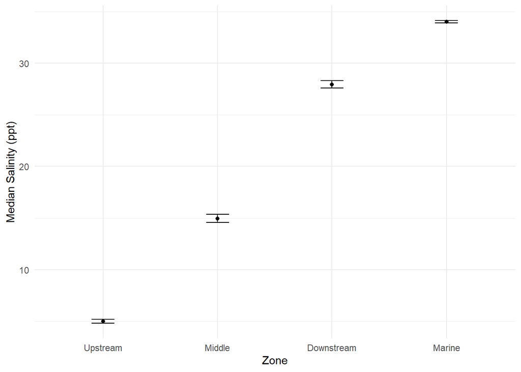

```r
# Let's make a table
sal_sum <-
  catch_data_final |>
  group_by(zone) |>
  summarise(
   # sem_salinity = sd(mean_salinity) / sqrt(n()),
    sd_salinity = sd(mean_salinity, na.rm = TRUE),
    median_salinity = median(mean_salinity, na.rm = TRUE),
    .groups = "drop"
  )

# And from this a plot
sal_sum |>
  ggplot(aes(x = zone, y = median_salinity)) +
  geom_point() +
  geom_errorbar(aes(ymin = median_salinity - sd_salinity, ymax = median_salinity + sd_salinity), width = 0.2) +
  theme_minimal() +
  labs(#title = "Median Salinity by Zone with Standard Deviation Error Bars",
       x = "Zone",
       y = "Median Salinity (ppt)")
```

There is a stark in salinity across the different estuarine zones, as expected and due to previous research being conducted on some of the fish species that have been mentioned within this dataset, we know how they respond to varying salinity gradients

Lets focus on tubidity now

#### TURBIDITY

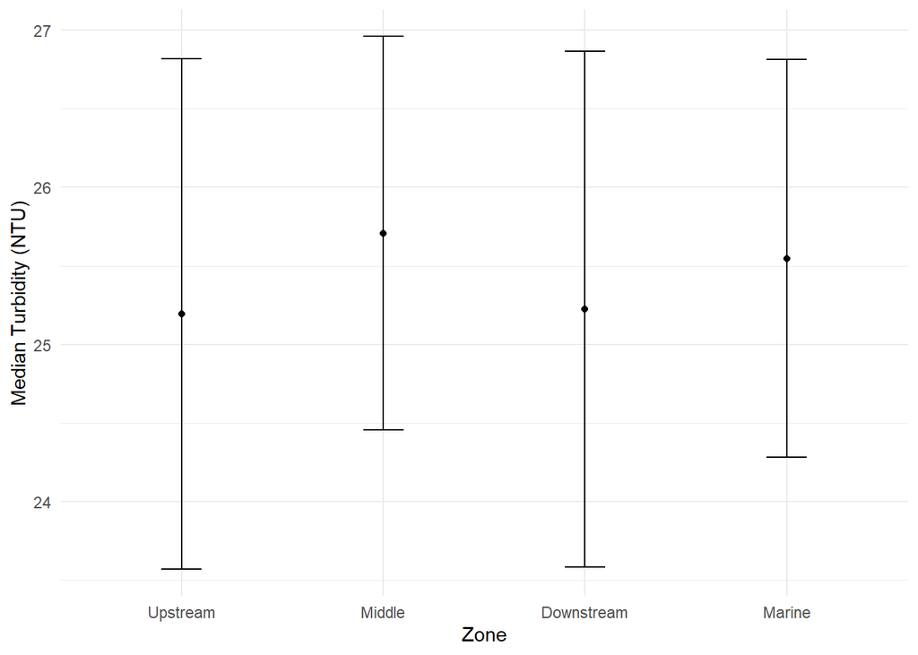

```r
turb_sum <-
  catch_data_final |>
  group_by(zone) |>
  summarise(
    sd_turbidity = sd(mean_turbidity, na.rm = TRUE),
    median_turbidity = median(mean_turbidity, na.rm = TRUE),
    .groups = "drop"
  )

turb_sum |>
  ggplot(aes(x = zone, y = median_turbidity)) +
  geom_point() +
  geom_errorbar(aes(ymin = median_turbidity - sd_turbidity, ymax = median_turbidity + sd_turbidity), width = 0.2) +
  theme_minimal() +
  labs(#title = "Median Turbidity by Zone with Standard Deviation Error Bars",
       x = "Zone",
       y = "Median Turbidity (NTU)")
```

#### TEMPERATURE

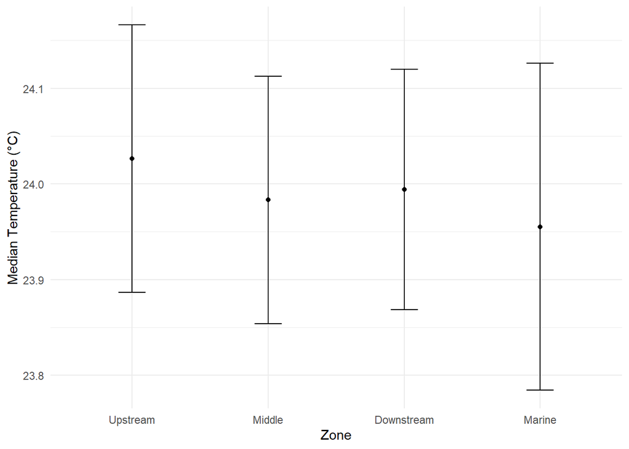

```r
temp_sum <-
  catch_data_final |>
  group_by(zone) |>
  summarise(
    sd_temperature = sd(mean_temp, na.rm = TRUE),
    median_temperature = median(mean_temp, na.rm = TRUE),
    .groups = "drop"
  )

temp_sum |>
  ggplot(aes(x = zone, y = median_temperature)) +
  geom_point() +
  geom_errorbar(aes(ymin = median_temperature - sd_temperature, ymax = median_temperature + sd_temperature), width = 0.2) +
  theme_minimal() +
  labs(#title = "Median Temperature by Zone with Standard Deviation Error Bars",
       x = "Zone",
       y = "Median Temperature (°C)")
```

Although we have seen a bit of variation within the turbidity levels across different zones within the Ross River estuary, we will still continue to use salinity as our main environmental variable of interest

## Remaking the salinity plot to make it publication ready

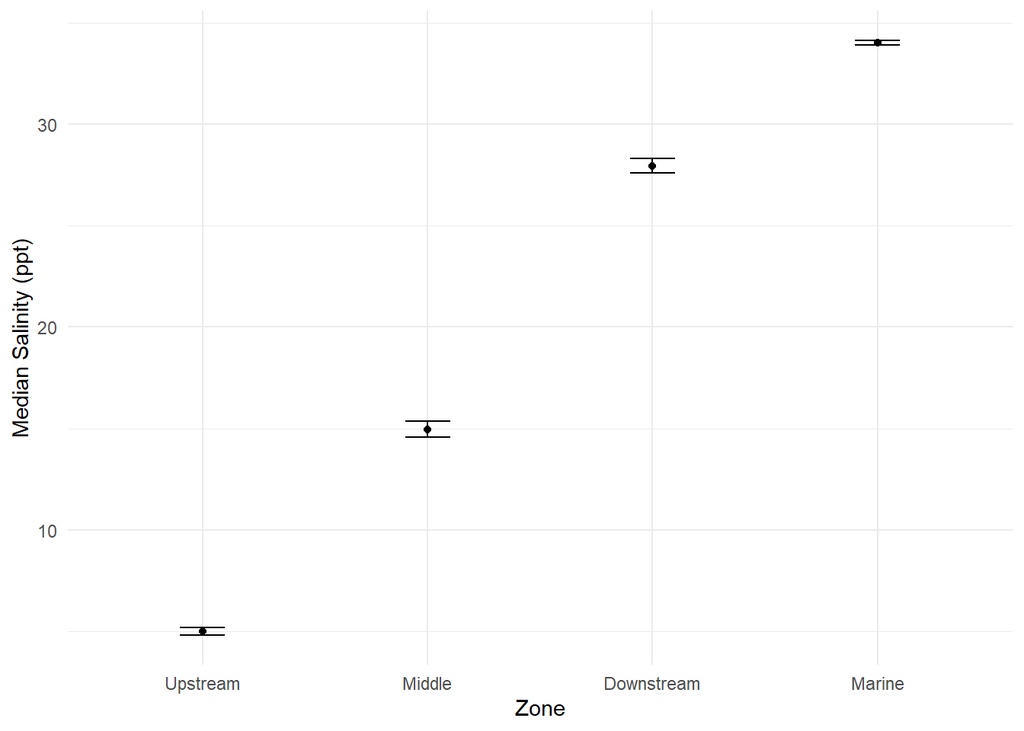

Salinity Gradient across zones. Ross River Estuary System, Townsville, NQ, Australia May 2026.

```r
sal_sum |>
  ggplot(aes(x = zone, y = median_salinity)) +
  geom_point() +
  geom_errorbar(aes(ymin = median_salinity - sd_salinity, ymax = median_salinity + sd_salinity), width = 0.2) +
  theme_minimal() +
  labs(#title = "Median Salinity by Zone with Standard Deviation Error Bars",
       x = "Zone",
       y = "Median Salinity (ppt)")
```

# Fish Abundance

```r
fish_stats <- catch_data_final |>
  group_by(zone, scientific_name) |>
  summarise(
    mean_catch = mean(count),
    sem_catch = sd(count) / sqrt(n()),
    .groups = "drop"
  )
```

## We can plot our graphs now for all four species of interest

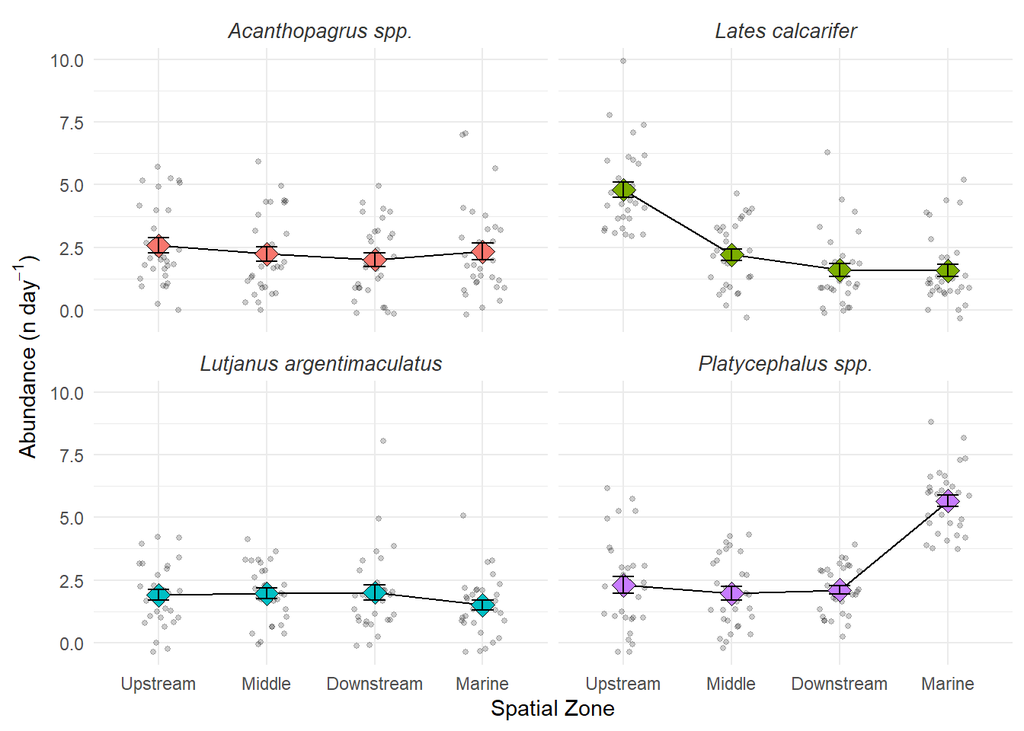

```r
fish_stats |>
  ggplot(aes(x = zone, y = mean_catch, fill = scientific_name)) +
  geom_line(group = 1) +
  # add in points from master data
  geom_point(data = catch_data_final, aes(x = zone, y = count),
             position = position_jitter(width = 0.2), alpha = 0.2, size = 1, inherit.aes = FALSE) +
  geom_point(position = "dodge", size = 4, pch = 23) +
  # SE pretty narrow, potentially not worth plotting but let's viewer see that included
  geom_errorbar(aes(ymin = mean_catch - sem_catch, ymax = mean_catch + sem_catch),
                position = position_dodge(0.9), width = 0.2) +
  facet_wrap(~ scientific_name, scales = "fixed") +
  theme_minimal() +
  theme(
    strip.text = element_text(face = "italic", size = 10, colour = "grey20"), # spp names in italic
   # legend.position = "bottom"
    legend.position = "none" # legend unnecessary
  ) +
  labs(
    #title = "Predatory Fish Abundance across Estuarine Salinity Gradients", # default ggplot title appears on top
    #subtitle = "Ross River Estuary System, May 2026",
    x = "Spatial Zone",
    # scientific label for y axis of n day -1 use regex to get superscript
    y = expression("Abundance (n day"^-1*")"),
  #  y = "Daily abundance (n day^-1)"
    y = "Abundance (per day)"
  )
```